# Apprentissage et agrégation de modèles

## Mise en place

On commence par charger les packages nécessaires à la réalisation du projet.

```r
# install.packages("rlang")
# install.packages("recipes")
# install.packages("FactoMineR")
# install.packages("factoextra")
# install.packages("doParallel")
# install.packages("devtools")
# devtools::install_github('topepo/caret/pkg/caret')
library(keras)
library(caret)
library(reticulate)
library(FactoMineR)
library(factoextra)
library(parallel)
library(doParallel)
```

On charge ensuite les données depuis keras et crée les variables d’intérêt.

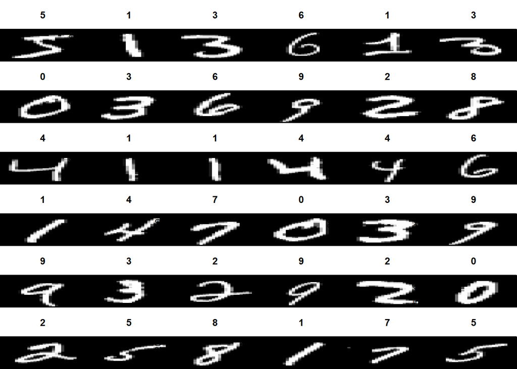

```r
# Chargement
mnist <- dataset_mnist()

x_train <- mnist$train$x
y_train <- mnist$train$y
x_test <- mnist$test$x
y_test <- mnist$test$y

# Visalisation
par(mfcol=c(6,6))
par(mar=c(0, 0, 3, 0), xaxs='i', yaxs='i')
for (idx in 1:36) {
  im <- x_train[idx,,]
  im <- t(apply(im, 2, rev))
  image(1:28, 1:28, im, col=gray((0:255)/255),
        xaxt='n', main=paste(y_train[idx]))
}
```

## Quesion 1

```r
# On applatit les matrices en vecteurs de dimension 2
x_train.plat <- array_reshape(x_train, dim=c(60000,784))
x_test.plat <- array_reshape(x_test, dim=c(10000,784))

# On cherche les positions des 0
liste.0 <- nearZeroVar(x = x_train.plat)

# On définit not in pour pouvoir trier les données
'%!in%' <- function(x,y)!('%in%'(x,y))

# on crée deux tables sans les 0 trouvés par nearZeroVar
x_train.propre <- x_train.plat[, 1:dim(x_train.plat)[2] %!in% liste.0]
x_test.propre <- x_train.plat[, 1:dim(x_train.plat)[2] %!in% liste.0]

# on vérifie que les dimensions sont bonnes
dim(x_train) ; dim(x_train.propre)
```

```
## [1] 60000    28    28
```

```
## [1] 60000   249
```

## Question 2

On veut réduire la dimension en faisant une ACP.Il serait plus rigoureux de faire une ACP sur l’enemble des données mais la version de MNIST utilisée est pré-découpée en x_train et x_test, j’ai donc réalisé une ACP sur chacune de ces deux parties et ensuite vérifié que les résultats de ces deux ACP étaient suffisament proches pour pouvoir les utiliser.

```r
# On fait une acp sur chaque partie
acp_train <- preProcess(x = as.data.frame(x_train.propre),
                        method = c("center", "scale", "pca"))
acp_test <- preProcess(x = as.data.frame(x_test.propre),
                       method = c("center", "scale", "pca"))

# On vérifie que les résultats sont similaires pour pouvoir continuer
compare_acp <- acp_train$rotation - acp_test$rotation # on veut des 0
sum(compare_acp) # on vérifie qu'il y bien des 0 partout
```

```
## [1] 0
```

Les deux ACP renvoient le même résultat, on peut don les utiliser pour la suite de l’analyse.

```r
pca_train <- PCA(x_train.propre, ncp=33, graph = F)
# on s'arrête à 80% de variance expliquée (j'ai testé 90% -> 90 variables = LONG)
x_train.red <- pca_train$ind$contrib

pca_test <- PCA(x_test.propre, ncp=33, graph=F)
x_test.red <- pca_test$ind$coord
```

## Question 3

Mon code pour cette question est disponible ci-dessous en commentaire car il ne fonctionne pas et est trop long à tourner. Après avoir beaucoup cherché la source de l’erreur que je reçois je n’ai toujours pas réussi à arriver à un code qui fonctionne pour le SVM. De plus, le temps d’exécution avant que l’erreur n’apparaisse est très long ce qui rend les tests difficiles, j’ai donc fini par abandonner cette question pour me concentrer sur la suite que je n’avais pas encore vu en cours.

```r
# d <- makePSOCKcluster(2)
# registerDoParallel(d)
# # on définit les paramètres du SVM et les paramètres à tester
# control <- trainControl(method='repeatedcv', number=5, repeats = 1)
# grid <- expand.grid(C=c(0.1,0.5), sigma=c(0.1,0.2))
# svm.carret <- train(y=as.vector(y_train), x=x_train.red,
#                     trControl=control, tuneGrid=grid,
#                     method='svmRadial')
# stopCluster(d)
#
# # On regarde la sortie obtenue
# plot(svm.carret) # C=0.5, sigma=0.1
# svm.carret$bestTune
#
# ## Test
#
# m.svm.pred <- predict(svm.carret, credit.te, type='raw')
# erreur.boost.b <- mean(m.svm.pred!=credit.te$default.payment.next.month)
```

## Question 4

On commence par mettre en forme les données.

```r
y_train.RNA <- to_categorical(y_train, 10)
y_test.RNA <- to_categorical(y_test, 10)
x_train.RNA <- x_train.plat / 255
x_test.RNA <- x_test.plat / 255
```

**Question 4.1**

On veut 10 LTU sur la dernière couche pour en avoir une probabilité d’appartenance à chaque classe (prédiction=probabilité la plus élevée). On réalise une classification, la fonction d’activation pour la dernière couche est donc softmax.

**Question 4.2**

On définit tout d’abord les couches et les parametres du modèle. J’ai testé plusieurs valeurs pour lr (0.1, 0.05, 0.01, 0.001 earning rate), qui ont amélioré progressivement le taux de bien classés - par exemple le passage de lr de 0.1 à 0.05 a doublé le taux de bien classés. Comme attendu, j’ai obtenu les meilleurs résultats pour lr=0.001, c’est donc cette valeur qui est présentée ci-dessous.

Pour avoir les graphiques keras, il faut lancer le fichier de code, ceux-ci ne s’affichent pas dans le markdown.

```r
# on définit les couches du modèle
model.RNA <- keras_model_sequential()
model.RNA %>%
  layer_dense(units = 784, activation = 'relu', input_shape = c(784)) %>%
  layer_dense(units = 10, activation = 'softmax')
adam <- optimizer_adam(lr = 0.001, beta_1 = 0.9, beta_2 = 0.999,
                       epsilon = NULL, decay = 0, amsgrad = FALSE,
                       clipnorm = NULL, clipvalue = NULL)

model.RNA %>% compile(
  loss = 'categorical_crossentropy',
  optimizer = adam,
  metrics = c('accuracy')
)

# on lance le modèle sur les données avec 10 cycles sur des lots de 200 données
predict.RNA <- model.RNA %>% fit(
  x_train.RNA, y_train.RNA,
  epochs = 10, batch_size = 200, verbose=0,
  validation_data = list(x_test.RNA, y_test.RNA)
)
predict.RNA$metrics
```

```
## $val_loss
##  [1] 0.14143148 0.09081598 0.07533827 0.07078368 0.07120280 0.06156466
##  [7] 0.06287208 0.05858682 0.06019764 0.06726598
##
## $val_acc
##  [1] 0.9570 0.9730 0.9779 0.9790 0.9767 0.9816 0.9806 0.9815 0.9822 0.9805
##
## $loss
##  [1] 0.279177108 0.110053315 0.071646615 0.052174672 0.037345323
##  [6] 0.028017277 0.020047206 0.015092863 0.011040963 0.008430237
##
## $acc
##  [1] 0.9209167 0.9684167 0.9791000 0.9848667 0.9893333 0.9923167 0.9951500
##  [8] 0.9963333 0.9977333 0.9983333
```

## Question 5

On commence par mettre en place les données. Sans array_reshape,, je recevais une erreur sur la forme de l’input(“Error in py_call_impl(callable, dots$args, dots$keywords) : ValueError: Error when checking input: expected conv2d_16_input to have 4 dimensions, but got array with shape (60000, 28, 28)”). Après avoir des solutions je suis arrivée à la conclusion qu’il fallait changer sa forme au préalabl, d’où la modification ci-dessous.

```r
x_train.CNN <- array_reshape(x_train/255, c(nrow(x_train), 28, 28, 1))
x_test.CNN <- array_reshape(x_test/255, c(nrow(x_test), 28, 28, 1))
input_shape <- c(28, 28, 1)

y_train.CNN <- to_categorical(y_train, 10)
y_test.CNN <- to_categorical(y_test, 10)
```

On définit ensuite les couches du modèle :

```r
model.CNN <- keras_model_sequential()
model.CNN %>%
  layer_conv_2d(filter=30, kernel_size=c(5,5),input_shape=input_shape,
                activation = "relu") %>%
  layer_max_pooling_2d(pool_size=c(2,2), strides = 2) %>%
  layer_conv_2d(filter=15, kernel_size=c(3,3), activation = "relu") %>%
  layer_max_pooling_2d(pool_size=c(2,2), strides=2) %>%
  layer_dropout(0.30) %>%
  layer_flatten() %>%
  layer_dense(units = 128, activation = 'relu') %>%
  layer_dense(units = 50, activation = 'relu') %>%
  layer_dense(units = 10, activation = 'softmax')
```

Rôle des couches :

- 1ere couche : applique 30 filtres sur des groupes de 5 par 5 pixels pour résumer leur information par une valeur à laquelle on applique la fonction d’activation relu (max(0,abs(x))).
- 2eme couche : réduit la dimension de la sortie de la 1ere couche en parcourant l’image en groupes de 2 par 2 pixels et gardant seulement la valeur max.
- 3eme couche : applique 15 filtres sur des groupes de 3 par 3 pixels pour résumer leur information par une valeur à laquelle on applique la fonction relu.
- 4eme couche : réduit la dimension de la sortie de la 1ere couche en parcourant l’image en groupes de 2 par 2 pixels et gardant seulement la valeur max.
- 5eme couche : retire chaque élément avec une probabilité de 30%.
- 6eme couche : applatit la matrice pour passer en dimension 2 (=array_reshape).
- 7eme/8eme couche : classifie les données sorties de la couche précédente en 128/50 groupes.
- 9eme couche : renvoie pour chaque observation les probabilités d’appartenance à chaque classe, le modèle de classification final assigne pour chaque observation la classe avec la plus haute probabilité.

```r
model.CNN %>% compile(
  loss = 'categorical_crossentropy',
  optimizer = adam,
  metrics = c('accuracy')
)

predict.CNN <- model.CNN %>% fit(
  x_train.CNN, y_train.CNN, verbose=0,
  epochs = 10, batch_size = 200,
  validation_data = list(x_test.CNN, y_test.CNN)
)
predict.CNN$metrics
```

```
## $val_loss
##  [1] 0.05279047 0.04559147 0.03669447 0.02843233 0.02768172 0.02587715
##  [7] 0.02830066 0.02344343 0.02502597 0.02765116
##
## $val_acc
##  [1] 0.9820 0.9846 0.9876 0.9912 0.9909 0.9908 0.9912 0.9920 0.9929 0.9913
##
## $loss
##  [1] 0.21499931 0.07572390 0.05894355 0.05203918 0.04397816 0.03824809
##  [7] 0.03528755 0.03504400 0.03163955 0.02953645
##
## $acc
##  [1] 0.9309833 0.9770000 0.9818167 0.9836833 0.9860667 0.9877167 0.9882167
##  [8] 0.9885667 0.9898167 0.9907167
```